Skip to the paper

MONTREAL.AI / RESEARCHFULL PAPER · ADDITIVE EDITION v4

**Contents — navigate the paper**

# AGI ALPHA FLYWHEEL — When Capability Creates Opportunity

## Transformational Intelligence, Experience-Trained Specialists and the Expanding Frontier of Profitable Work

**Vincent Boucher — President of MONTREAL.AI**

**Additive opportunity-discovery edition v4 · 27 October 2026**

**FIND YOUR ALPHA. BUILD YOUR SUCCESSOR Ω.**

# Abstract

We investigate whether expert frontier-AI operation can discover an opportunity, construct a reusable instrument and a viable offering, and leave a successor better equipped for useful work. A bounded opportunity portfolio precedes a manufacturing inspection-evidence experiment on actual NIST/MTC sources. The constructed instrument combines exact QIF semantics, CAD witnesses, permutation-invariant record reasoning and source-specific acquisition plans. The original frozen version passes 5/8 independent scoped audits; a separate recipient’s actual executable transfer passes, with no physical acceptance and no advantage over an identical-content ordinary library. A separately versioned repair passes 4/4 prospectively frozen new missions on the same historical data. A small hosted same-model trial yields U4/4, E4/4 and E+3/4 strict accepted jobs; a lenient E+ reading yields parity, and complete costs remain unknown. A frozen conditional economic experiment finds no new feasibility crossing against the expert baseline across eleven stresses and rejects the proposed six-horizon retention investment. A subsequent contractual audit exposes a milestone-refund contingency missing from the original financing model. The contribution is an executable, inspectable lineage and a disciplined limit: numerical invariance can equip new evidence questions, while physical identity, current authority, participation and financing still require their own evidence. No autonomous market creation, earned commercial Alpha, specialist ASI or commercial compounding is established. All original failures and source versions are preserved.

**Keywords:** transformational intelligence; Operational Alpha; inspection evidence; QIF; STEP; selective inheritance; market design; cash timing.

# The question this edition can answer

A useful answer resolves a request. A reusable instrument changes the preparation needed for later requests. A commercial arrangement determines whether somebody can afford to construct and maintain that instrument. These are connected propositions, but none implies the next.

This additive edition investigates that connection through a concrete receiving- quality problem: **when can evidence produced by one inspection provider support a different recipient’s stated obligations, and what exact evidence is missing when it cannot?** A successor may need to investigate a particular feature rather than assess a collection of measurements. Reuse becomes valuable only if the instrument preserves those differences in purpose.

The opportunity was selected after exploration, not supplied as a finished benchmark. We retained ten serious directions and challenges, rejected a current software-defect premise when an authoritative new release passed the reported failure, and grounded the selected manufacturing problem in actual NIST/MTC CAD and inspection records. The existing NIST integrated graphs, established geometry methods and commercial products are starting assets available to the expert comparator. They are not inventions of this study. [4–9]

The resulting instrument constructs source-bound numerical and geometric witnesses, preserves alternative correspondences, and produces a precise acquisition plan. Its strongest lesson concerns the boundary between a useful answer and an unauthorized substitution. Some universal statements about recorded values survive an unknown permutation of individual feature labels. That does not identify a hole for rework, establish which physical specimens were measured, or release a part. Moreover, the exact QIF schema makes a plausible-looking unit repair a hypothesis rather than a fact. The public source data therefore supply both a construction opportunity and a serious falsifier.

This is a hybrid research edition. Programs, source parsing, CAD imports, numerical witnesses, process transfer, signatures and accounting interfaces are executed. Potential buyers, prices, commercial quality probabilities, financing and cash flows are modeled separately. No customer was recruited, no physical measurement was purchased, no live production authority was granted, and no customer revenue was earned. Complete research cost is unknown because hosted inference billing and human effort were not available. A successful local run cannot fill those gaps.

## Contribution and limits

The new contribution is an executable lineage linking opportunity selection, mission-specific evidence, a retained instrument, fresh recipient checks and a commercial stopping decision. It is not a new STEP/QIF standard, a new geometric matching algorithm, the first digital thread, or evidence of general autonomous market invention. The retained instrument can be useful without establishing scientific novelty or commercial superiority. The study tests those stronger claims separately and preserves negative outcomes.

The lineage has six distinct evidence stages:

1. An independently motivated engineering need and a prior-art challenge.
2. A Plate-only construction using literal source semantics and actual geometry.
3. A frozen runtime and independently curated unfamiliar Box/Cover requests.
4. A separate recipient, unchanged generic structure and fresh mission authority.
5. A small same-model operating-method comparison.
6. A prospective offering and retention policy with complete modeled cost and cash distinctions, including the option to stop.

A result at one stage does not automatically admit the next. In particular, computational usefulness does not establish demand, a positive modeled expected contribution does not establish liquidity, and possession of code does not establish authority to execute it.

## Additive custody

The repository parent is `231834269599d85e49cfe1ca9917a1a874522d44`. The inherited research/runtime bridge is pinned to `80b345828f34fd8a6e592977dd17ef37141305f4`, with its complete source manifest. The three canonical foundational PDFs were read in full; their editable TeX sources and exact file hashes are retained. No directly attached file identities were visible; we do not assert byte equivalence to unseen attachments. [1–3]

Earlier papers, corrections and implementation lanes remain intact. The microgrid/storage formulation developed earlier in this session is explicitly preserved as a historical fixture, not this edition’s flagship. Its supplied formulation, selected-case improvement and later failed mission are not renamed as autonomous discovery. The prior cheap hosted comparison’s U/E/E+ parity and its unknown complete costs also remain in the record. Current owners of runtime, specialist relay, enterprise, release publication and adjacent research lanes were coordinated through issue #4850; this edition claims none of their reserved release versions or production permissions. [16]

# Three foundations, one mechanism

## Transform the means while preserving the purpose

*Transformational Intelligence: Learning to Change the Game* separates the useful purpose, its operational formulation and the evaluation instrument. A transformation needs a constructed alternative, a realization in the original setting and a falsifying observation. Novelty to a recipient is different from novelty to science. Its finite causal example does not demonstrate unrestricted invention, and an ordinary unrestricted planner can match the transformed policy. [1]

Here, the potentially removable restriction is an unnecessary demand for a complete one-to-one label reconstruction before answering a symmetric question. If the question is whether all selected recorded values satisfy a common interval, reordering the values cannot change the answer. The replacement is a source-bound universal check, accompanied by explicit coverage and identity conditions for stronger physical claims. If the original question instead asks which hole to rework, the restriction is not removable in this way. The instrument must retain that distinction.

## Construct the offering and the capability together

*Invent the Economy* treats the technical capability, counterparties, transfers, responsibilities, financing, timing, rights and evidence as one possibility package. Technical feasibility, modeled viability, accepted arrangements, realized exchange and repeatable markets are different stages. Aggregate surplus cannot substitute for each participant’s consent. [2]

The new proposed offering is a fixed-scope audit plus an optional commissioned generic adapter and private adaptation. The buyer decides against its own configured tools, an integrator, a corrected export, remeasurement, deferral or no purchase. A shared generic component may reduce repeated engineering, but it also costs money and carries correlated failure risk. A contribution arrangement can move cash earlier only by specifying what the buyer receives and which failure risk the buyer accepts. It cannot repair missing specimen identity.

The original example remains numerically unchanged: four assumed buyers each pay USD300,000 after success; common construction costs USD600,000; each conditional delivery costs USD75,000; common qualification succeeds with probability 0.8. Successful contribution is USD300,000, expected contribution is USD120,000, and opening prefunding is USD900,000. The four buyers share the common failure. These are synthetic assumptions, not evidence of actual demand or learned capability. [2]

## Inherit stable structure, then earn fresh acceptance

*Transformational Autonomous Enterprises: SUCCESSOR Ω Harness* retains identity, program, schema, dependencies, scope, provenance and cost. Generic qualification can be reused only under complete unchanged identity and the evaluator’s policy. The new mission’s semantics and authority remain fresh obligations. Its reduction from 1,600 to 64 generic qualification cases concerns that category only; the supplied direct specialist remained faster in the final comparison. It did not measure a 96% customer saving or prove the commercial price target. [3]

This edition applies the principle to executable readers, proof routines and geometry adapters. A recipient receives the actual small runtime closure, while large public inputs and installed native dependencies remain separately identified. The recipient rebinds the current request and all source hashes, verifies a fresh local research grant, invokes a separate process and passes an independent checker. An expired grant, changed source or different purpose cannot be revived by the generic cache. The ordinary-library control receives identical bytes and permissions, so any equality is retained rather than credited to a graph.

## What joins the foundations

The original 0.1.0 runtime identity binds the construction witness, qualification and actual recipient receipt. An explicit proposed offering package names the separate corrected version 0.1.1, its acceptance evidence, outside options, responsibilities, rights and financial assumptions. The recorded recipient handoff remains a 0.1.0 result. That package was assembled after the results; it is a concrete proposal, not a prospectively executed sale. The frozen economic program is artifact-agnostic: it did not gate transactions on these technical results or calibrate quality and costs from them. Its assumed common component has the instrument’s proposed scope, not a measured commercial yield.

The same mission boundary is preserved in the audit, proposed outcome and transfer check. The financial model distinguishes required delivery from additional retention and optional research, and can reject construction. This links a real capability and its possible arrangement while leaving the remaining acceptance, demand and cost evidence explicit. It does not establish an executed end-to-end commercial flywheel. The machine-readable proposal is `offering/package.json`.

# Exploration before selection

## Budget and search discipline

The first portfolio assigned three researchers two materially different candidates each, targeting at most eight focused searches and four deep primary sources per candidate. A separate prior-art challenge examined laboratory protocol transfer. Concrete contradictions justified documented extra lookups. When no flagship survived the first round convincingly, a second bounded round assigned each researcher at most five searches and three deep primary sources. No paid API calls, purchases, customer outreach or hardware access were made. This is a declared search-work budget, not a measured dollar budget.

Each serious candidate records beneficiary, useful outcome, observed difficulty, existing coverage, remaining conjecture, construction required, decisive test, falsifier and a commercial mechanism. Ordinal scores organize researcher judgment; they are not success probabilities or market forecasts. Hard gates include an independently useful purpose, a gap that survives a strong incumbent, inspectable evidence, and clear limits when fresh physical trials are unavailable. The complete dossiers and selection record precede flagship runtime construction.

| Direction | Consequential possibility | Reason it was not selected, or selected |
| --- | --- | --- |
| Agent counterexamples | Turn observed execution failures into reusable tests | Generic trace-to-test/review tools already cover much of the initial proposition; no adequate independent incident bank was secured. |
| Scientific dependency repair | Preserve scientific meaning across software changes | Real need, but target-specific requirements and fresh outcomes were not yet secured. |
| Causal biological evidence repair | Choose evidence that resolves cross-context decisions | Causal assumptions and unfamiliar measured outcomes were unavailable. |
| Liquid handling as rheology | Reuse robotic motion as an experimental instrument | Substantial existing work; a fresh apparatus and reference measurements were required. |
| Additive-manufacturing fatigue transfer | Reduce repeated qualification testing | Strong prior art and inadequate protected physical holdout. |
| Mission-relative thermal metrology | Decide when incomplete tensor identification is sufficient | Convenient examples lost their gap after known symmetry and manufacturing information were supplied. |
| Laboratory protocol transfer | Make protocols portable across instruments | Existing executable frameworks invalidated the broad novelty claim. |
| Scientific compute-to-artifact handoff | Verify that a finished job leaves a valid deliverable | A specific old corruption report reproduced, but the current authoritative software passed. |
| Scientific evaluation contracts | Preserve scientific targets through composed pipelines | Credible reserve direction; corrected benchmarks and agentic review already form a strong baseline. |
| Cross-provider inspection evidence | Reconcile actual source semantics and produce actionable evidence repair | Selected after a complete Plate geometry/result trace and concrete cross-provider contradictions. |

## The runtime pilot changed the decision

The runtime candidate was attractive because a nominally completed write can leave an unusable scientific artifact. A bounded pilot reproduced the reported Zarr 3.1.3 / Dask 2025.9.1 ZIP failure. The analogous path passed with Zarr 3.4.2 / Dask 2026.8.0; conventional local-store and array-creation controls passed. Initial stalled attempts are preserved, with no unsupported causal diagnosis. At most four attempts per environment were authorized. The current release removed this particular repair opportunity before a general instrument was built.

The system receives no credit for the upstream improvement. This negative result also demonstrates obsolescence: an operating advantage can disappear when ordinary defaults improve. Unused reanalysis and weather source snapshots remain identified as unused exploration, not as scientific workloads we executed.

## Why manufacturing passed the construction gate

The selected packet belongs to an actual public NIST/MTC three-component manufacturing experiment. It contains first-article reports, incoming inspection, CAD and manufacturing records. A separate reference dataset already links incoming inspection and AP242 design information. The original archive contains an AP203 geometry model; the later reference archive contains AP242 models. Those revisions are not interchangeable by filename. [4–7]

The remaining bounded question is cross-provider comparability under a stated mission, not extraction of an already supplied incoming graph. The Plate pilot found a complete measured-feature-to-CAD path and contradictory semantic facts: same-looking labels can denote different nominal dimensions; standard and material-condition declarations differ; a tolerance literal is negative; provider specimen identifiers have different forms; and a passing diameter can belong to an overall failed inspection. Exact unit semantics sharpened the problem further.

Existing capabilities remain substantial. NIST’s 2024 integration work already addresses spatial and temporal feature association. Capvidia advertises persistent QIF identifiers, design-to-inspection traceability and derivative validation; CompareVidia compares geometry and semantic PMI; ZEISS PiWeb supports supplier-quality comparisons, sorting and filtering. These establish meaningful expert alternatives, not measured performance on our packet. Their vendor ROI claims are not simulation inputs. [7–9]

The opportunity is therefore conditional: can a reusable, auditable treatment of these heterogeneous obligations lower complete adaptation and verification work for a recipient whose existing chain is incomplete? If the recipient’s configured system already supplies the same complete result efficiently, the new instrument offers no established advantage.

# The constructed instrument

## Inputs, custody and supported semantics

The reusable asset is an executable QIF 2.1 evidence reader, source-identity checker, numerical proof routine, CAD correspondence witness and repair-request generator. A request binds the useful mission to exact input hashes. Its output preserves literal values, source object identifiers and line references, formal SI quantities, parent inspection status, geometric candidates, conditional claims and unresolved evidence. Unknown purposes or unsupported versions fail closed. A successful CLI exit means that a report was produced, not that its claims have passed independent acceptance.

The caller supplies a typed purpose and, for explicit family tests, the selected characteristic identifiers. The instrument does not infer unrestricted mission semantics from prose. The curator’s stated obligations and independent checker establish the meaning of these bounded tests; supplied scope IDs are not credited as autonomous discovery.

The bounded predicates concern diameter intervals and cylindrical-feature correspondence. Unsupported characteristic kinds remain visible source facts; they are not coerced into diameter logic. A negative geometric tolerance is reported literally. The code does not take its absolute value. Standard names, material-condition modifiers and specimen identifiers are compared without pretending that a matching nominal proves equivalent metrology.

The two downloaded source archives are frozen by SHA256. Their sizes are 248,727,407 bytes for the original NIST/MTC experiment and 10,680,120 bytes for the reference graphs/models archive. Compact per-experiment input packs preserve the actually used bytes. The original Cover incoming file and the reference version differ, unlike the matching Plate incoming copies. A byte difference invalidates exact cached identity; it does not by itself prove a semantically wrong graph. The current mission must inspect the difference and its relevance.

Source schemas, public data, researcher-authored requests, executable constructions and simulated preferences have separate provenance. Source hashes establish byte identity, not correct scientific interpretation or rights. NIST notices and third-party schema terms remain attached to the relevant artifacts.

## An actual requirement-to-geometry witness

Plate development imported one valid AP242 solid with 261 faces, 722 edges and 34 cylindrical faces. All 18 incoming cylindrical feature definitions had geometric candidates under the declared coordinate and unit policy. The frozen instrument constructed 17 incoming characteristic/feature traces, selecting an observed actual result for each supported pair. These are structural counts within one part, not independent trials.

One complete trace is incoming definition 99, nominal 100, characteristic 101, feature 97, and actual 102. The linked CAD candidate includes face index 93; its raw STEP entities include advanced face #7281 and cylinder #7269. The actual diameter is 3.017 mm. Its encoded local interval is satisfied, while the containing inspection’s overall status is FAIL. The source’s local result therefore cannot be promoted into whole-part acceptance. The witness is useful precisely because it preserves both conclusions.

The geometric computation uses installed OpenCascade through CadQuery. The independent reviewer uses a separate parser and direct OCP reimport, but shares the underlying geometric kernel. This is implementation separation, not an independent physical measurement or a second CAD kernel. Spatial proximity and compatible cylinder parameters support a candidate correspondence. They do not supply missing cross-provider specimen or feature identity.

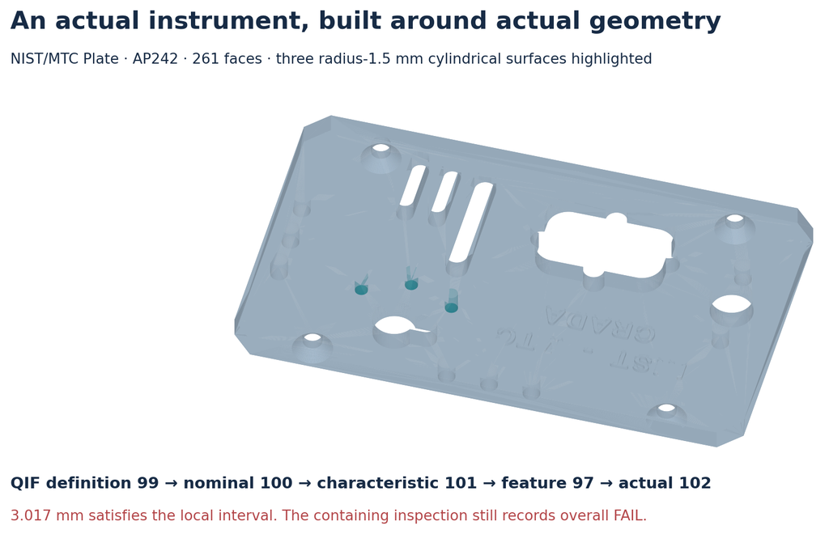

Actual Plate geometry and the local-result/overall-status distinction. The geometry is computed from the public AP242 source, not generated imagery.

## Exact units change the answer

The standards owner’s archived QIF 2.1 `LinearValueType` and `ActualLinearValueType` rules default to meters when neither a value-level unit nor the applicable primary unit supplies a replacement. The FAIR files lack that metadata; incoming inspection explicitly uses millimeters. [10] A raw FAIR value such as 3.026 therefore cannot silently be interpreted as 3.026 mm simply because that seems plausible for the part.

For the Plate development family, 60 recorded raw values lie between 3.026 and 3.065. Under the formal source interpretation, they cannot support the incoming millimeter interval. Under an explicitly supplied millimeter-repair hypothesis, the source interval [2.75, 3.25] mm is contained in the destination interval [2.746, 3.254] mm and all selected values satisfy the latter. These are separate results. The second does not authorize a corrected export or establish what the producer intended.

The unit ruling is appended to the selection history rather than replacing its preceding uncertainty. A qualified source owner could provide corrected metadata with revision provenance; a buyer could then authorize evaluation of that new source. The current instrument neither manufactures that evidence nor treats a researcher’s guard label as an authenticated assertion.

## The permutation formulation

Let the exact selected records be a finite multiset $X=\{x_1,\ldots,x_n\}$ with an independently justified unit interpretation, and let the receiving predicate be membership in a single interval $I$. For every permutation $\pi$ of those same records,

$$\bigwedge_{i=1}^{n}[x_i\in I]
=\bigwedge_{i=1}^{n}[x_{\pi(i)}\in I].$$

This familiar symmetry supplies an executable shortcut: checking the universal record statement does not require discovering an individual label permutation. If each source interval $J_i$ is contained in $I$, then every value allowed by those source intervals also satisfies $I$. The implemented witness reports both interval inclusion and the actual recorded-value check. Neither substitutes for the other: passing labels under a wider source interval do not establish a narrower destination requirement, and a theoretical inclusion claim cannot excuse an actual value outside the destination.

For feature-specific work the claim changes. If two admissible correspondences associate a different source feature with the named target, an invariant family summary does not locate that target. The instrument constructs such assignment counterexamples. For physical-family work, a separate proof must establish that the selected source records cover the required destination members and specimens. A numerical statement over 400 selected records can be valid while that coverage is unknown. No cheaper evaluator is substituted for the original stronger task.

The tool exposes five purposes: evidence audit, all selected recorded values, complete feature family, individual feature localization and physical release. The record-only purpose was made explicit during development because requiring a physical bijection for every numerical record query would be an impossible and irrelevant hurdle. The already curated stronger confirmation requests kept their original purposes. Any later record-only diagnostic is reported separately.

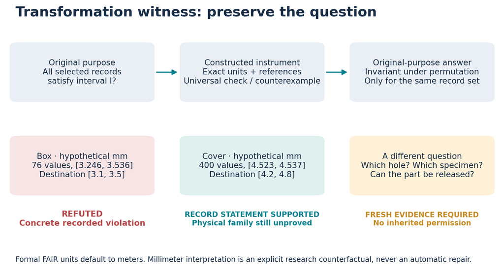

The transformation preserves the exact record question. Hypothetical unit repair does not supply physical coverage or permission.

## Transformation witnesses

| Element | Universal recorded-value decision | Cross-provider physical substitution |
| --- | --- | --- |
| Original useful purpose | Determine whether all exact selected recorded values satisfy a specified interval | Establish that another provider’s evidence satisfies the buyer’s physical obligations |
| Binding restriction | Treating individual label reconstruction as necessary for a symmetric numerical predicate | Missing units, identity, coverage, semantics, measurement adequacy and authority |
| Why removable or not | A permutation of the same finite records leaves a conjunction unchanged | These are material evidence requirements, not merely awkward representations |
| Construction | Exact reader, interval check, inclusion witness and violating-value/assignment certificate | Typed missing-evidence plan; fresh qualified evidence would be required |
| Realization | Source-bound calculation over actual records, keeping the stated unit hypothesis explicit | Current records remain blocked or refuted; a hypothetical correction is separate |
| Falsifier | One missed value, unsound unit conversion, false universal claim, or a task that actually needs an individual identity | Any automatic physical admission from a numerical proof or cached graph entry |

This is an instrument built with known mathematics. An established expert given the same formulation can compute the record predicate with ordinary interval checks. This mathematical comparison is not a timed solver experiment. It locates a potential source of value in selecting and applying the right question and preserving its boundaries; it does not demonstrate a superior new solver. The study does not establish that subsequent discovery campaigns invent better formulations more efficiently. Testing that would require multiple independent campaigns with frozen discovery policies and comparable opportunity-search costs.

# Independent confirmation and fresh inheritance

## Frozen development and independent checking

Development used Plate only. Version 0.1.0 froze 116,202 bytes of runtime sources, schemas, policy and unit evidence. Its compact runtime ZIP is 26,848 bytes. Eleven targeted Plate tests passed. An earlier geometry-unit policy incorrectly rejected a valid millimeter model because an annotation also mentioned inches; that failed candidate and report remain preserved. The correction examined only the geometry context and preceded protected confirmation.

A separate curator prepared eight main Box/Cover jobs and one reserved recipient mission without disclosing their answers to the core developer. The independent checker froze after 19 adversarial development tests. It independently parses XML, computes Decimal quantities and finite permutations, checks source references and status ancestry, and reimports CAD. It does not call the instrument’s proof functions as its oracle. All fresh reports, failures and elapsed observations remain in the evidence companion.

Protection was procedural: separate agent context and explicit file-access rules on a shared host. The source datasets are public and come from one historical assembly. This is retrospective unfamiliar-task evaluation, not an independent industrial sample, a blinded human trial or a guarantee against pretraining contamination. Thousands of checked fields are not thousands of independent examples.

## First protected result: 5 of 8 accepted scoped audits

The frozen version accepted no physical substitution or part release. It produced correctly bounded family, localization and release analyses, but the independent checker accepted only **5 of 8** complete scoped audits. Three unspecialized audit reports failed the predeclared actionability requirement: two repair entries lacked bindings to the affected source obligations. The program’s own `supported_audit` label did not override the independent failure.

| Original request | Independent result | Consequential finding |
| --- | --- | --- |
| Box report comparability | Fail | Useful traces existed, but two repair requests lacked affected-object bindings |
| Cover report comparability | Fail | Same actionability defect |
| Box formal family | Pass as a refuting audit | Formal unit interpretation rejects the proposed numerical implication |
| Box hypothetical millimeter family | Pass as a refuting audit | An actual recorded value still violates the receiving interval |
| Cover hypothetical millimeter family | Pass as a bounded audit | Selected records pass numerically; complete physical-family coverage remains unproved |
| Box feature localization | Pass as an insufficiency audit | Family reasoning cannot identify the individual cross-provider feature |
| Cover physical release | Pass as a scope assessment | Physical release remains unsupported; no part was accepted |
| Cover audit without CAD | Fail | Missing geometry is explicit, but two repair requests lack affected-object bindings |

“Pass as an insufficiency audit” means the contracted research question was answered with a useful, checked reason. It does not mean that a customer buying physical substitution or release received its promised outcome. Blanket abstention would fail the useful-work requirements.

The Box family makes the distinction tangible. Source characteristic IDs 14, 20, 26 and 32 supply 76 recorded values. The incoming interval is [3.1, 3.5] mm. Even under the explicit millimeter hypothesis, the observed range reaches 3.536 mm; actual 988, result set 984, records 3.506 mm, already outside the upper bound. A source PASS under its wider interval is insufficient.

Cover supplies a different result. Twenty nominal-4.5 source characteristics produce 400 values, hypothetically 4.523–4.537 mm, all within the destination [4.2, 4.8] mm interval. Their universal recorded-value conclusion is invariant under permutation. The destination’s represented family has four feature identifiers, however; the twenty source characteristics do not establish its physical coverage. The stronger family request remains blocked. These opposite outcomes were not supplied as convenient training labels to the core developer.

## What the successor actually received

The existing lifecycle moved a 43,242-byte transport bundle containing the 116,202-byte application closure and its manifest. The recipient used 8,238,065 bytes of separately bound public source data. Approximately 1.09 GB of installed native dependencies were rehashed and checked rather than transferred in the small application bundle. Receiving the wrapper therefore does not mean independently acquiring OpenCascade, a frontier model or a specialist’s weights.

The reserved Cover mission asked a process engineer to plan the additional exact evidence needed before combining provider results for investigation. It did not ask for a new measurement, a machining cause or release permission. A fresh local Ed25519 research grant bound the recipient, complete request, source manifest, runtime and dependency identities, scope, validity interval and nonce. The inherited native Journal recorded nonce consumption. The actual CLI ran in a separate process and the independent checker accepted the resulting acquisition audit. Physical reuse remained false.

The transfer exercised 35 study controls, all passing, and the unchanged lifecycle’s 29 controls. Mutated bytes, changed missions/dependencies/sources, expired or revoked grants, invalid signatures, absent execution rights and replayed authority were refused. These are finite conformance checks, not live ENS authentication or a proof of hostile-host security. Names ending in `.agent.agi.eth` are modeled identities in this fixture.

The actual recipient CLI took 3.012 seconds; the recipient execution including dependency checks took 4.993 seconds. These narrow observations exclude model research, engineering, independent evaluation, maintenance and customer effort. They are not complete service latency or dollar cost. Six generic packaging and runtime-integrity cases were reused as zero repeated cases under exact identity; current source, mission, dependency and authority checks still ran.

An ordinary library with identical content and permissions also produced an accepted, semantically identical report. Thus **graph-specific value was not established**. The concrete retained value is executable structure and fresh qualification, not the storage label. The native production capsule correctly rejected manufacturing as an unsupported scope. No runtime scope, Jobs validator role, governance rule, revocation mechanism or settlement interface was broadened.

## A prospective repair, with the first result preserved

The unbound repair requests were reproduced on an unspecialized Plate request. The source instrument was not rewritten in place. A separate version 0.1.1 binds every repair to the declared mission and the actual source/receiving characteristic, nominal, definition and measurement-record obligations. An explicit family request narrows that scope; an unspecialized audit binds the complete declared collections. Scope membership does not assert a cross-provider correspondence.

Before the developer changed the code, the independent curator froze four new requests and their actionability criteria. The developer received the generic defect description but did not inspect their source IDs, values, requests or answers. Thirteen Plate-only checks passed; the revised runtime and a separate evaluator adapter then froze. All **4 of 4** prospective requests passed on their first calls, with no retries. Summed subprocess wall time was 19.884 seconds and independent checking 1.194 seconds.

These are new mission tests on the same already-used historical collection. They are not independent physical data and do not replace the original 5/8 result. The original runtime, checker, reports, fresh-recipient transfer and failed repair bindings remain immutable. The original nine distinct missions comprise eight primary jobs plus the accepted reserved recipient, or 6/9 scoped audits; the ordinary-library replay is a control, not a tenth independent mission. The separate prospective repair result is 4/4.

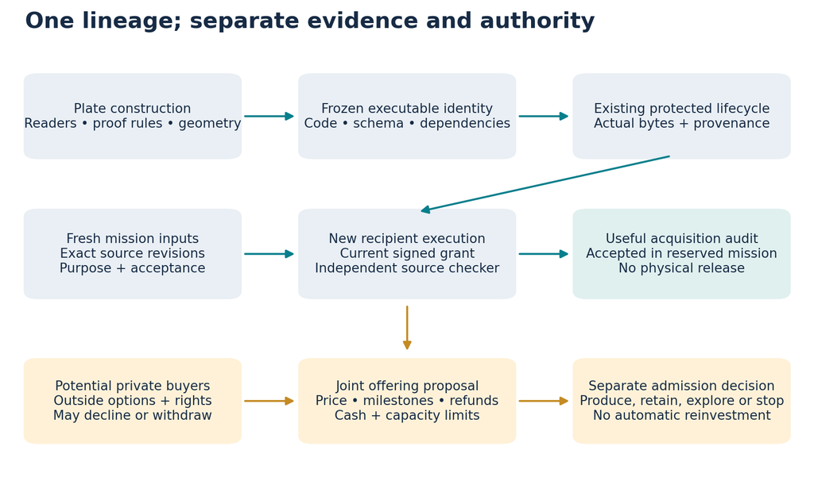

Capability, current mission, authority and commercial arrangement remain linked but separately checked.

# Operational Alpha: a proportionate actual test

## Fair configurations

Operational Alpha is the advantage of using the same available frontier intelligence more effectively. It can arise from selection, formulation, context, prompting, decomposition, tool execution, experiment design, verification, correction or coordination. It need not be a new algorithm. The additional value of a newly retained method is a separate comparison. Profits that already assume expert operation cannot count that advantage again.

| Reference | Meaning in this edition | What was actually measured |
| --- | --- | --- |
| H | Scope-matched human/integrator service | Estimated hours/rates only; no human trial or matched quote |
| U | Competent ordinary request to the same inherited hosted-model configuration, with tools and correction permitted | Four useful source-analysis jobs |
| E | U plus established engineering practice: purpose, provenance, semantics, calculation, checking and bounded claims | The same four jobs and source/tool ceilings |
| E+ | E plus a newly retained, versioned operating method | The same four jobs; the large instrument and completed reports were withheld |

U was not forced into a weak prompt, denied tools or prevented from using known methods. All arms received the exact public files, useful source selectors, a conventional XML-reading example, the exact unit schema and existing NIST reference graphs. The stronger E procedure did not monopolize ordinary access to good evidence. Conversely, expertise is not defined away as valueless Beta. The question is whether these particular methods add measured value for this recipient under this test.

The retained method was constructed from Plate development: name the exact purpose and quantifier; bind the claim to literal source objects; execute the smallest discriminating calculation; provide a falsifiable witness; and give a decision-specific evidence request. The original artifact is the expert procedure; the environment is the Plate source packet; feedback consists of concrete unit, identity and purpose failures; the update is an authored operating-policy file. It is workflow refinement, not weight training or reinforcement learning. Its version and the evaluation packet/rubric froze before confirmation.

## Fresh recipients and resource accounting

Three independent conversations without parent history answered four fresh Box/Cover requests. Each had an eight-tool-call ceiling and a 1,600-word final answer ceiling for the complete packet. All could run bounded local analysis scripts and correct errors within that ceiling. They could not inspect protected answers, sibling responses, prior reports or the retained instrument’s code. Only E+ received the candidate method. The shared host provides procedural separation rather than an adversarial filesystem boundary.

This is a cheap prompting experiment alongside the more ambitious construction. It does not make prompt collection the flagship. Four jobs and one frozen rubric are proportionate; no additional training campaign was run simply to obtain a positive result. The paid-job learning bucket remains zero for the actual study, because these are unpaid research tasks.

| Arm | Strict accepted jobs | Mandatory criteria | Self-reported tool calls | Answer words |
| --- | --- | --- | --- | --- |
| U | 4/4 | 24/24 | 7 | 1,239 |
| E | 4/4 | 24/24 | 6 | 1,185 |
| E+ | 3/4 | 23/24 | 8 | 1,207 |

The E+ failure is narrow and preserved. Its H4 response correctly identified component 528 and the full specimen serial in one passage, then instructed the operator to verify “serial 528’s specimen.” The strict frozen criterion requires consistent distinction between component ID and specimen serial, so the job failed. A lenient reading would accept 4/4; that sensitivity is disclosed and still supplies no E+ acceptance advantage. This is not evidence that the method generally harms performance. E+ also corrected one execution error within its budget; scripts and logs preserve the correction.

E versus U therefore shows acceptance parity at the matched observable ceiling. E’s one fewer self-reported tool call is a descriptive difference, not a complete cost saving. E+ versus E establishes no additional learned Alpha in this test. The data do not justify a population effect estimate from four related jobs. No model-upgrade advantage is credited to either comparison.

Exact inference tokens, provider billing, active model latency and complete customer effort are unavailable. They are recorded as null, not zero. Tool and output ceilings are matched; exact monetary budgets are not. At matched accepted quality, U and E each completed all four jobs, but complete-cost superiority remains unmeasured. E+ did not achieve the same strict accepted quality. The observable artifact is a complete, reproducible set of responses and analysis scripts, including failures; the commercial conclusion is that no measured method premium has yet been earned.

# Commercial construction with the possibility of rejection

## The offering is a joint package

The prospective buyer receives a fixed-scope evidence-sufficiency audit: exact source inventory, checked conclusions for specified obligations, witness or counterexample, and a precise request for what remains. Full substitution, physical reinspection and part release require separate contracts. The supplier must have permission to provide the relevant records; the receiving organization owns its acceptance and release decision; a laboratory supplies actual measurement and uncertainty evidence; an integrator supplies the digital deliverable.

Common construction may include generic readers, proof predicates, geometry adapters and verification. Customer CAD, specimen records, private requirements and clarification remain private. Generic success does not accept any private mission. A potential buyer may prefer a configured incumbent, hire another integrator, obtain a corrected export, repeat inspection, defer or decline. No coalition is presumed merely because several files use QIF.

No scope-matched public service quote was found within the declared search. Accordingly H is explicitly estimated: 12–31 team hours at an assumed blended USD125–225/hour gives USD1,500–6,975 for an unfamiliar heterogeneous packet. A configured recipient’s separate estimate is 2–8 hours, or USD250–1,800. Neither is a measured human result or a wage claim. Licenses, unusual onboarding, physical metrology and other applicable costs require actual quotations. No salary or compensation anecdote values the method. [8–9]

The simulated delivery costs and quality probabilities are also assumptions. They are **not calibrated from the small hosted trial or the 5/8 first instrument result**. A hypothetical 0.94 common qualification probability does not certify version 0.1.0. The commercially admissible deployment remains unestablished even when a conditional modeled package has positive profit.

## Participation, price and risk allocation

The frozen experiment draws one to seven separate potential needs per horizon, including outside-option prices, value, effort, configuration, compatibility and rights. It then searches every subset, six posted prices from USD500 to USD6,000, and a bounded menu of advance/refund terms. No fixed discount, buyer count, training allocation or reinvestment fraction is imposed. Equal posted prices are a declared search restriction, not a claim of globally optimal bargaining.

Let $V_i$ be the buyer’s value for an accepted audit, $H_i$ its outside-service price, $q_i$ the assumed acceptance probability, $P$ the offered price, $a$ the advance fraction, $r$ the failure-refund fraction and $e_i$ its effort cost. The outside utility is $\max(V_i-H_i,0)$. Under the commissioned-development hypothesis, the buyer participates only if

$$q_i V_i-\{q_iP+(1-q_i)(1-r)aP\}-e_i
\geq \max(V_i-H_i,0).$$

The nonrefundable share is not a guaranteed-audit payment. It pays for a separately specified development record and failure artifacts, and is earned only upon acceptance of that contracted milestone. If that record is not accepted, a full refund is due under the proposed contract. The frozen numerical model assumes that this development record is always accepted, including after audit failure; it does not draw a separate milestone-rejection event. Its partial-refund cash and profit results are conditional on that assumption. This is an unvalidated contractual hypothesis, not legal advice or an observed accepted arrangement. The full-refund scenario removes the spendable-financing benefit by changing the terms; it does not independently simulate milestone rejection. A separate adverse solvency audit below examines that omitted contingency without changing the original results. No speculative resale value of failed code is added.

The search maximizes modeled expected contribution conditional on stated commitments, then observes prelaunch withdrawal and replans before construction. It is not a solution to the entire sequential bargaining game. Buyers’ hidden technical, delivery, default and withdrawal events are generated only after the planner selects its package; future outcomes are not fields in the planner’s buyer objects. Adverse realizations can still lose money.

## Complete costs and cash

The model keeps three disjoint buckets. A includes commissioned common construction required for the sold work, preparation, conditional delivery, serving, support, failed attempts and bad debt. B includes additional retained qualification and upkeep. C includes additional prospect/research assessment, including an assessment that ends in stopping. Optional Gym expenditure is zero because no campaign was justified, not because training is assumed free.

Actual work in this edition is unpaid research. It is not relabeled as paid-job learning. In a separate six-horizon diagnostic, initial exploratory construction is charged in C once, with initial retention and later transfer in B. It is not charged again as paid-job A. Labor in the model is assumed cash contractor expense; displaced-production opportunity cost is not charged a second time.

Cash follows dated events, with seed, advance collections, unearned obligations, refund reserves, invoices, final collections, refunds, expenses and writeoffs separate. Earned revenue is not identical to collections. Refunds of unearned advances are not revenue reversals of an already accepted audit. Default creates bad-debt expense rather than an invented negative collection. Fully refundable advances create no spendable development financing under the conservative reserve rule. Required opening cash funds all committed precollection work and promised audit-failure refund reserves without borrowing against unpaid invoices, conditional on acceptance of the development milestone. It does not establish solvency under the proposed full-refund remedy for rejection of that milestone.

An initial development ledger generated each buyer’s full timeline before the next buyer’s early costs. Its final profit and conservative prefunding calculation were unaffected, but its intermediate cash plot was wrong. That version and its receipts are preserved. Before confirmation, all events were queued and replayed chronologically; a two-buyer check requires every delivery expense to precede final collections. This correction is not a change to favorable economic assumptions.

## Fair mechanism comparisons

Four ablations use identical current needs, permissions, 80-hour capacity and opening cash: expert bespoke work with payment on acceptance; retained instrument with payment on acceptance; expert work with the optional commission arrangement; and retained instrument with the arrangement. An unrestricted enterprise can choose any of them or stop. Thus the ablations isolate mechanisms without pretending that experts cannot propose commercial alternatives.

A package is modeled feasible only if each participant prefers it, rights are present, expected contribution after A/B/C is nonnegative, assumed acceptance probability is at least 0.85, required cash fits the same seed, work fits 80 hours, and delivery fits the ten-business-day resource envelope. These thresholds were frozen before confirmation. They are a model definition, not an achieved service level or physical acceptance standard.

The experiment includes compatible and incompatible jobs, efficient incumbents, negative transfer, common technical failure, withdrawal, partial/private failure, payment default, refunds, support and maintenance. Eleven declared scenarios stress opening cash, common cost, demand, transfer, incumbent efficiency, contract refunds, payment/withdrawal, ordinary-model progress and quality obsolescence. These are assumption perturbations. Scenario counts or quantiles cannot validate the assumed market.

## The frozen commercial result

The primary confirmation contains 80 fresh assumed horizons per scenario and four arms, for 3,520 simulated arm-horizons. The table below reports the central assumptions; complete scenario rows and source hashes are supplied.

| Configuration | Financeable horizons / 80 | Accepted simulated audits | Mean simulated contribution, USD |
| --- | --- | --- | --- |
| Expert, payment on acceptance | 74 | 118 | 2,324.09 |
| Retained instrument, payment on acceptance | 27 | 57 | 492.72 |
| Expert, commissioned-development terms | 75 | 121 | 2,476.92 |
| Retained instrument plus those terms | 38 | 84 | 771.24 |

The central result favors the already available expert offering. Commercial coordination improves financing for some retained packages, but the combined configuration has **zero new feasibility crossings against the expert standard baseline**, across all eleven declared stresses. Cases in which both qualify are not new economic possibility. In the central scenario, all 38 combined feasible horizons already qualify under the expert standard alternative.

Positive stand-alone contribution for the retained package does not establish incremental Alpha. Its mean contribution is lower than the expert alternative; initial construction, additional retention and imperfect transfer matter. The decline is not hidden as a new opportunity cost inside A: it is reported as a comparison between complete alternatives. Conversely, modeled profitable expert delivery remains a valid conditional result even when retention is rejected.

The financial mechanism remains inspectable. In one explicitly selected example (seed 21001), three assumed buyers each pay USD4,000, with a 75% advance and 50% failure refund. Final modeled net collections are USD12,000, projected expenses USD5,810.073726 and profit USD6,189.926274. Seed capital of USD6,000 brings terminal cash to USD12,189.926274; the seed is not revenue. The same accepted outcomes and final payments under payment-on-acceptance terms have the same total contribution, but a tighter precollection cash position. This illustrative path is not the mean or a customer sale.

The original dated events were recorded through the inherited signed Journal. The unchanged native CostLedger received only a settled projection: A USD5,310.073726, B USD400 and C USD100, with commissioned common construction charged once. Twelve conformance checks passed. The native ledger does not gain an invented advance-liability feature; the fuller research cash ledger remains authoritative for timing and obligations. An initial floating-point serialization was correctly refused by the signing interface; the preserved repair used decimal strings and original event hashes without changing the scenario.

## Adverse contractual-solvency audit after confirmation

Editorial review identified the unmodeled development-milestone rejection condition. A separate protocol, calculation program and source hashes were frozen before an adverse calculation over all 3,520 original rows. The original commercial program, prices, selections and results remain unchanged. This is a post-confirmation stress audit, not new market confirmation or recovered profit.

For each originally selected financeable package, independently reconstructed common construction, all committed private preparation/delivery/support, retention and assessment determine the full precollection cash cost. If all advances must then be refunded and no final collection finances the work, required opening cash equals that full cost: the advance and its refund cancel. The audit compares that requirement with the same scenario seed. It assumes committed work is incurred, so an exposure is a conditional cash requirement, not a claim that the original realization became insolvent.

| Original configuration | Selected plans across eleven scenarios | Exposed to full milestone-refund condition | Maximum additional opening cash needed, USD |
| --- | --- | --- | --- |
| Expert, payment on acceptance | 772 | 0 | 0 |
| Retained instrument, payment on acceptance | 127 | 0 | 0 |
| Expert, commissioned-development terms | 796 | 62 | 3,311.46 |
| Retained instrument plus those terms | 194 | 52 | 5,222.25 |

Thus 114 of 1,889 selected commitments have this adverse funding exposure. Eleven of those commitments were later cancelled in the original withdrawal realizations; the table assesses the original commitments, not only delivered packages. Under central assumptions, exposure affects 2 of 75 expert-arranged plans (maximum USD559.57) and 15 of 38 retained-arranged plans (USD739.85). The original full-refund-contract scenario has no additional exposure. All per-scenario counts and exact cost reconstructions are retained separately.

The independent input reconstruction matched all 36 retained buyer objects; the maximum reconciliation difference against the original partial-refund cash formula was below USD0.000000000002. These checks validate this calculation, not its market assumptions. No rejection probability or revised expected profit is inferred. Disputed or partial acceptance, other contractual nonperformance, legal enforceability, credit and late-payment behavior remain outside this adverse audit. Actual customer collections and earned revenue remain zero, and actual complete research cost remains unknown.

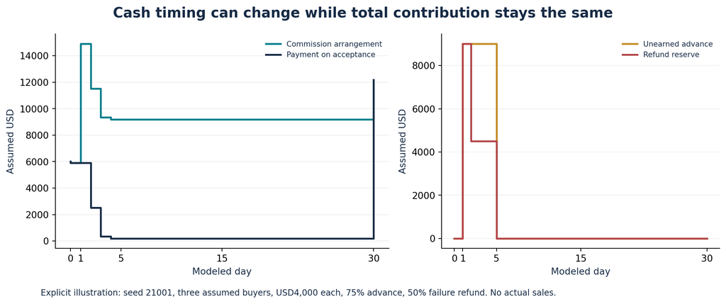

One explicitly selected simulated cash path. Advances, unearned obligations and reserves are separate from earned contribution.

## Retention can be rejected without denying useful capability

A separate prospective six-horizon admission policy used development seeds only. Under favorable preexisting-instrument assumptions, its estimated incremental benefit was USD2,220.94. Proposed new research construction, initial retention and fresh-recipient transfer totaled USD2,950. The policy therefore rejected the campaign before confirmation. The chosen policy’s incremental expenditure and incremental gain are both zero; ordinary production remains available. The diagnostic charges USD100 of additional upkeep only in horizons that use the retained arm; it assumes no idle-upkeep charge when expert work is selected. This favorable maintenance assumption is not an observed operating cost.

For diagnosis, twenty forced-construction paths then charged the full initial USD2,800 and USD150 transfer at horizon four, held capacity constant and capped spendable cash at USD6,000 each horizon. Their mean final incremental net value was **−USD1,049.79**, with only two of twenty paths nonnegative. These hypothetical paths do not retrospectively admit the rejected campaign or recover profit. The ordinary library with identical contents and permissions has the same path; no graph-specific premium is assumed.

This is a concrete stop decision rather than a claim that valuable skills do not exist. The initial finite benefit upper-bound check was reachable and the incremental comparison included an efficient expert. The campaign loses under its stated assumptions. A lower construction quote, stronger demonstrated transfer or independently evidenced reuse could justify a new prospectively frozen policy; none is substituted after seeing these outcomes.

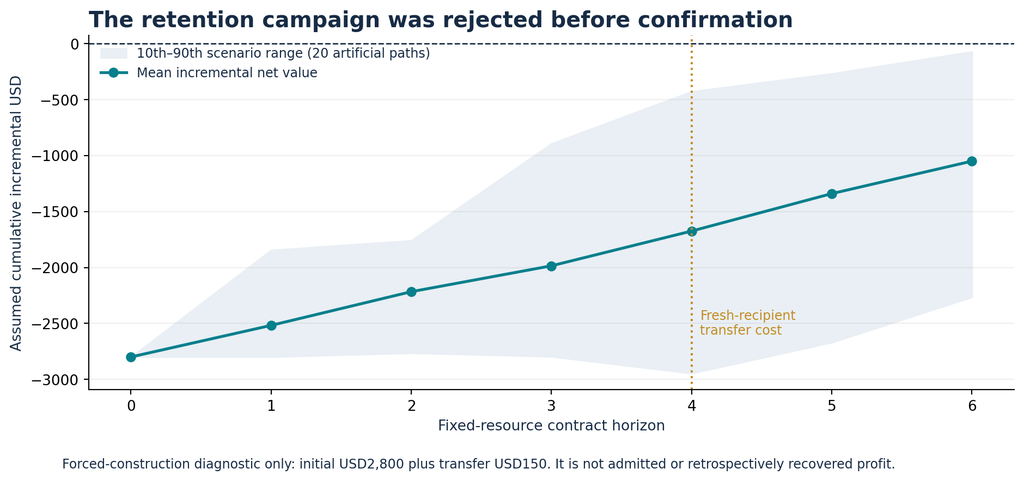

A forced-construction diagnostic after prospective rejection; it does not recover or admit profit.

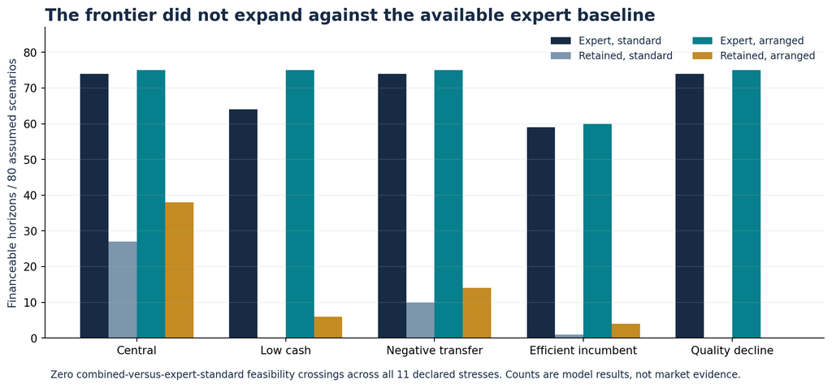

The modeled productive frontier remains unchanged against the expert alternative.

# What becomes possible next

The executable work changes what a successor can inspect without reconstructing every reader, reference chain and proof routine. It exposes a valid permutation-invariant record question, a real counterexample on a new part and a useful evidence-acquisition mission. It also leaves a clearer specification for corrected source exports and later metrology. These are actual computational assets and accepted scoped outputs, subject to the recorded failures.

The stronger frontier did not move in this edition. Physical report substitution, individual cross-provider localization and part release remain unsupported by missing evidence. No new commercial feasibility crossing was established against the available expert baseline. No surplus-funded increase in agents, compute or jobs was used to manufacture compounding. A larger graph, more report fields, a lower parser runtime or positive hypothetical market size would not change those conclusions.

This boundary is operationally useful. Produce when the existing expert service meets acceptance and participation. Construct when a complete proposal earns its cost and fits cash. Retain or share when expected recipient reuse justifies the additional qualification and upkeep. Buy new evidence when an actual unresolved claim requires it. Preserve cash or stop when those conditions fail. The program does not require every loop to run.

# Operating blueprint

## A concrete initial offer

Offer an authorized, bounded inspection-evidence assessment for one stated part/revision and an agreed set of obligations. Specify the expected output before intake: a complete source inventory, traceable conclusions or counterexamples, identified uncertainty, and a decision-specific acquisition plan. Quote separately for physical measurements, correction of authoritative exports, new proprietary adapters, individual feature localization and release support. A purchase of a complete substitution decision cannot be closed by renaming an insufficiency report as success.

Obtain the buyer’s actual outside option: its configured QIF/PLM chain, an existing integrator or laboratory, and its ability to defer. The unfamiliar-packet H estimate is unsuitable for a recipient whose current system already resolves the question in a few hours. Seek a matched quote or timed trial before turning any assumed price into a commercial claim. The research supplies no geographic market-size estimate; USD is only the model’s numeraire. Its six horizons are contract-cycle scenarios, not a forecast of worldwide demand.

## Deliver expertly

Intake can automatically inventory file versions, hashes, schemas, units and scope, but it cannot invent rights or a missing authority revision. Execute the smallest useful source and geometry checks. Preserve literal signs, current standards and parent status. A reviewer checks material conclusions against source-derived evidence; the need and duration of residual review are measured when performed, not imposed as arbitrary routine minutes.

Separate three outputs in every report: numerical entailment, evidence sufficiency for the requested physical claim, and current permission. When a claim fails, produce the exact violating value or unresolved relation, not an unhelpful blanket refusal. When evidence is missing, ask for the smallest authorized item that could resolve it. Examples are a corrected units declaration with revision provenance, a relevant feature mapping, a specimen/lot relation or a task-specific uncertainty statement. No whole confidential archive is required by default.

Track preparation, tool/model usage, failed attempts, correction, checking, customer clarification, delivery and support. A low runtime for the final script is not a complete accepted-service cost. If the existing configured method is better, use it rather than forcing the retained tool into every job.

## Construct and retain selectively

The potentially shareable asset is generic executable code and its operating policy, with schemas, dependencies, declared scope, source provenance, evidence, limitations and upkeep costs. Customer-specific designs, inspection data, restricted intellectual property, protected answers and private clarification stay outside the package. Rights to process a file do not imply rights to redistribute it or train a model on it.

Admission should inspect whether a hurdle can be satisfied before purchasing a large evaluation. Bound the plausible benefit from compatible current or independently evidenced future reuse, subtract additional assessment, retention, serving and maintenance, and compare with the recipient’s actual baseline. A failed or rejected candidate still incurs its costs. If a policy is corrected, retain its old decisions and test the new policy prospectively.

Successful paid delivery may yield candidate expertise. This edition’s actual research is not paid delivery. Its method update is a versioned operating artifact; it is not weight training or a demonstrated specialist ASI. A Gym campaign would need an initial policy, environment, feedback, update rule, budget and resulting version, with diverse development tasks and independent fresh evaluation. Reward exploitation, contamination, negative transfer and obsolescence are explicit rejection conditions. Workflow refinement is an economical first option; model fine-tuning or reinforcement learning is not assumed available or necessary.

The frozen economics reject additional retention in the tested finite portfolio. Accordingly no mandatory Gym or sharing expenditure is manufactured. Research transfer still tests the mechanism under separately granted authority, without claiming commercial admission. Access to a specialist service would preserve service utility; it would not make each recipient independently possess that specialist’s intelligence.

## Participation and financing

A shared generic adapter can be negotiated across independent private projects without pooling customer CAD. Each counterparty sees the common deliverable, its private adaptation, price, rights, timing, responsibility, refund and support terms. Conditional commitments must be attractive individually, not merely in aggregate. A shared technical failure is a correlated event.

An advance creates cash and an obligation together. Finance only against the spendable portion permitted by the agreed milestone and reserve rules. Recheck withdrawal and capacity before launch. Keep paid development, generic qualification and private acceptance distinct. Collect after the relevant acceptance and expose remaining receivables/default risk. Never count seed, customer savings, token issuance or an estimated opportunity value as earned revenue. A positive expected contribution with unaffordable prefunding is a stop or renegotiation decision.

## Multi-agent coordination that actually occurred

The team separated opportunity research, core construction, independent curation/checking, integration/accounting, and publication. Agents exchanged an interface contract, source identities and freeze notifications rather than silently sharing protected answers. The independent reviewer detected an actionability defect that the core’s own status label did not catch. The integration worker delivered actual bytes to a separate process and invoked the independent checker. The hosted method recipients used separate conversations without parent history and common source/tool ceilings.

This is actual task coordination on a shared host, not institutional independence or proof that a larger swarm is intrinsically better. No agent count is treated as commercial gain. The same-content library matched the graph control. Repository coordination remained in issue #4850 with existing owners; no competing registry or production execution lifecycle was created.

## Protected access and intended token utility

For a future admitted, rights-cleared capability, currently eligible `*.agent.agi.eth` agents should be able to discover and request access through the protected network. Eligibility must still be followed by current recipient, mission, scope, source and authority checks. Revocation, expiry, Jobs validator roles, governance and settlement remain authoritative. The present local signature fixtures are not live ENS authentication, and the native manufacturing scope remains unqualified.

The intended utility of $AGIALPHA concerns concrete coordination mechanisms: funding eligible jobs or budgets, escrow and contractual settlement, worker and validator incentives, and governed access or reserves where implemented by the current system. Existing source implementations and the earlier local-EVM fixtures must not be described as this edition’s live token transactions. [3,16] Scientific capability, token access, legal classification, token market value and enterprise cash profit are different quantities. This study measures no token valuation and reaches no legal classification conclusion. Its accounting simulation uses USD and contains no token issuance or exchange-rate subsidy.

## Frontier-model operation and obsolescence

The hosted team used frontier reasoning with local code execution, XML/CAD tools, source research and independent correction. The current official model documents were checked on 27 October 2026. `gpt-6-astra` is the verified reasoning identifier; `gpt-6.1-terra` is an available execution/computer-use candidate; model choice should remain role-dependent and updateable. The verified standard prices were USD10/1/50 per million input/cached-input/output tokens for Astra and USD1/0.05/5 for Terra. Longer-context and service-tier multipliers require their own checks. These are sourced API prices, not observed billing for this hosted study. [11–13]

The current hosted interface does not expose a complete served API snapshot, inference-token ledger or customer billing attribution. No Terra computer-use experiment or proprietary-weight update was claimed. ChatGPT Pro is a plan, not an API model identifier or automatic access entitlement. No weak no-tool substitute is treated as the ceiling of frontier AI. No measured gain is credited to a model upgrade in the U/E/E+ comparison. The software pilot and model-default stress both show why a retained advantage must be requalified as ordinary tools improve.

## Before live operation

The remaining work is concrete: independent prospective engineering acceptance on genuinely different industrial packets; actual human/integrator quotes or trials; buyer-specific rights and source-owner corrections; measured customer interaction, complete model/tool/support costs and service latency; accepted contracts and financing commitments; and owner-led production scope and security qualification. None is satisfied by publishing this research draft. The next commercial commitment should be a small scoped pilot whose promised outcome, price, refund rules and acceptance can be reviewed before work begins.

# Interpretation and limitations

The work establishes an inspectable construction and a bounded computational transfer. It does not establish autonomous demand discovery, a general invention algorithm, independent customer value, specialist ASI, positive learning Alpha, or commercial compounding. The original requirements make those distinctions necessary; they are not reasons to suppress useful narrower results.

The manufacturing data are public, historical and related. Model contamination cannot be ruled out. The numerical invariance is established mathematics, and all expert arms may use it. The CAD checker shares a kernel with the candidate. The source files lack evidence needed for physical reuse. The initial instrument failed three useful-report requirements. Native production scope rejects this domain. The market and cost parameters are uncalibrated hypotheses; the first observed acceptance result does not validate their assumed quality. Hosted resource ceilings are matched only in observable calls/output, and complete costs remain unknown.

These limits identify the next decisive tests. A genuinely unrelated packet would challenge transfer; a buyer’s configured workflow would challenge added value; a timed accepted-delivery trial would challenge cost; a signed conditional commitment would challenge participation; and a cash-prefix ledger with actual payment terms would challenge financing. A new independent discovery campaign would be needed to test whether the enterprise has learned to find opportunities more efficiently. None can be replaced by increasing synthetic sample count.

The $15 quadrillion projection and intellectual-property superlatives on the original AGI Alpha vision site are treated as external promotional claims. They supply no market-size, willingness-to-pay, asset-value or growth parameter in this study. [14] We do not estimate a total addressable market, extrapolate hypothetical savings across sectors, or count a customer’s savings and the enterprise’s revenue as two independent additions to value.

# Conclusion

The opportunity search left behind more than a selected benchmark: preserved rejections, a current-software falsification, a real manufacturing evidence instrument, exact semantic counterexamples, an independently checked recipient handoff and a prospective rule that can decline further investment.

The most useful transformation is specific. A universal question about selected records can survive unknown label permutations; a question about a physical feature or release still needs its missing evidence. The successor inherits the reader and proof structure while rechecking meaning and earning current authority. The commercial test is equally specific: existing expert delivery remains the strong alternative, the simulated combined offering does not create a new feasibility crossing, and the tested retention campaign should stop.

That result preserves the AGI Alpha ambition without spending its conclusion in advance. Profitable delivery can be a foundation; expert operation can create legitimate advantage; retained instruments can equip later work. In this edition, what is demonstrated is the instrument and the discipline needed to distinguish those possibilities from earned Alpha. The next expansion must be earned through new evidence.

# Authorship, assistance and publication status

**Vincent Boucher — President of MONTREAL.AI.** This exact attribution is supplied by the commissioning author. Research, code, analysis, translation and editorial preparation were performed with AI assistance in this session. The role-separated reviewers are AI agents on a shared workspace, not independent human peer reviewers. Public sources, researcher-supplied structures, observed executions, corrections and simulated quantities are identified separately.

This is a versioned additive research edition, not a software release or an owner-approved production claim. Browser-readable Markdown, PDF, editable LaTeX, reproducible code/data, evidence companion, executive brief and English/French demonstration accompany it. Public draft publication uses a dedicated source branch and review process. Canonical Pages/catalogue and release publication remain with their authorized owners.

# References and source custody

All web-source checks are dated 27 October 2026. Source facts, vendor capabilities and model documentation are distinguished from this study’s own computations. Complete archive/member hashes and notices appear in the data manifests.

1. **Boucher, V. / MONTREAL.AI.** *Transformational Intelligence: Learning to Change the Game*. Exact repository edition at runtime source freeze, 24 pages. [PDF](https://github.com/MontrealAI/AGI-Alpha-Agent-v0/blob/80b345828f34fd8a6e592977dd17ef37141305f4/docs/Transformational_Intelligence.pdf). SHA256 begins `d7170e8217e3`.
2. **Boucher, V. / MONTREAL.AI.** *Invent the Economy: Transformational Intelligence for Creating Viable Markets*. Exact repository edition, 22 pages. [PDF](https://github.com/MontrealAI/AGI-Alpha-Agent-v0/blob/80b345828f34fd8a6e592977dd17ef37141305f4/docs/Invent_the_Economy.pdf). SHA256 begins `61e92a47b32c`.
3. **MONTREAL.AI / Writer #4.** *Transformational Autonomous Enterprises: SUCCESSOR Ω Harness*. 23 October 2026 edition, 29 physical pages. [PDF](https://github.com/MontrealAI/AGI-Alpha-Agent-v0/blob/80b345828f34fd8a6e592977dd17ef37141305f4/docs/papers/transformational-autonomous-enterprises-v1.pdf). SHA256 begins `640cba6e0371`. Historical attribution retained.
4. **NIST.** *Defining the Requirements for Integrating Information between Design, Manufacturing, and Inspection*. [Publication record](https://www.nist.gov/publications/defining-requirements-integrating-information-between-design-manufacturing-and); [full public article](https://pmc.ncbi.nlm.nih.gov/articles/PMC11167730/). Existing integration difficulties and experiment context; not proof of a current unserved market.
5. **NIST/MTC.** *Design, Manufacturing, and Inspection Data for a Three-Component Assembly*. [Publication](https://www.nist.gov/publications/design-manufacturing-and-inspection-data-three-component-assembly), [dataset DOI](https://doi.org/10.18434/T4/1503154), [J. Res. NIST 124, 124.004](https://nvlpubs.nist.gov/nistpubs/jres/124/jres.124.004.pdf). Original archive hash begins `6bc4693f4b07`.
6. **NIST.** *Reference Knowledge Graphs of STEP and QIF Data for a Three-Part Box Assembly*. [Dataset DOI](https://doi.org/10.18434/M32146), [official archive](https://data.nist.gov/od/ds/mds2-2146/qif-ontology-dataset-V2.zip). Archive hash begins `9ae303335274`. Supplied graphs/models are existing baseline assets.
7. **NIST / CCAM.** *Spatial and Temporal Data Alignment from Disparate Sources for Feature Association*. NIST GCR 24-050, 2024. [DOI](https://doi.org/10.6028/NIST.GCR.24-050), [report](https://tsapps.nist.gov/publication/get_pdf.cfm?pub_id=957946). Strong prior art for feature association, not a method invented here.
8. **Capvidia.** [MBD Ready for OEM](https://kb.capvidia.com/docs/mbd-ready-for-oem), updated 4 September 2026; [CompareVidia](https://www.capvidia.com/products/comparevidia); [Solutions](https://www.capvidia.com/solutions). Advertised persistent traceability, model/PMI comparison and integration services. No vendor ROI percentage is used as a study parameter.
9. **ZEISS.** [PiWeb data analysis](https://www.zeiss.com/metrology/en/software/zeiss-piweb/data-analysis.html). Supplier comparison, sorting, filtering and notifications. No scope-matched fixed engineering-service quote obtained.
10. **DMSC.** [QIF 2.1 owner archive page](https://qifstandards.org/qif-2-1/), [exact archive](https://qifstandards.org/wp-content/uploads/2015/03/QIF-2.1.zip). `QIFLibrary/Units.xsd` SHA256 `2d46993e49300841e66fc05c35dafbcb63ac8085e9c9c8cbc8670e97c13a5fbd`. DMSC copyright/permission notice accompanies redistributed schema bytes; this material is not relicensed as Apache or public domain.
11. **OpenAI.** [GPT-6 Astra model documentation](https://developers.openai.com/api/docs/models/gpt-6-astra). Current API identifier/capabilities/prices, distinct from hosted study telemetry.
12. **OpenAI.** [GPT-6.1 Terra model documentation](https://developers.openai.com/api/docs/models/gpt-6.1-terra). Role-appropriate execution/computer-use candidate; not an executed Terra trial here.
13. **OpenAI.** [API pricing](https://developers.openai.com/api/docs/pricing). Standard token rates and service/context qualifications require current verification before operation.
14. **AGI Alpha Agent vision.** [agialphaagent.com](https://agialphaagent.com/). Motivation only. The quoted USD15 quadrillion and IP superlatives are external promotional claims, not validated findings or forecast inputs.
15. **Scientific software incident and version controls.** [Xarray issue 10840](https://github.com/pydata/xarray/issues/10840), [Zarr issue 3516](https://github.com/zarr-developers/zarr-python/issues/3516), [official stable storage documentation](https://zarr.readthedocs.io/en/stable/api/zarr/storage/index.html). Exact packages, attempts and artifacts are frozen in the runtime pilot dossier. The executed current-version pass is our observation, not inferred from a release note.
16. **MONTREAL.AI AGI-Alpha-Agent-v0.** [Repository](https://github.com/MontrealAI/AGI-Alpha-Agent-v0), [coordination issue 4850](https://github.com/MontrealAI/AGI-Alpha-Agent-v0/issues/4850), [this lane’s selection update](https://github.com/MontrealAI/AGI-Alpha-Agent-v0/issues/4850#issuecomment-6447631102). Research parent and immutable runtime bridge identities appear in the reproducibility manifest.
17. **NIST.** [STEP File Analyzer and Viewer](https://www.nist.gov/services-resources/software/step-file-analyzer-and-viewer), [current source repository](https://github.com/usnistgov/SFA). Existing geometry/PMI inspection belongs in the expert baseline.
18. **NIST.** [Copyright, Fair Use, and Licensing Statements](https://www.nist.gov/open/license), updated 24 June 2025. Apply dataset-specific notices and distinguish third-party/extramural material; do not assign a blanket license to every archive member.

The full opportunity dossier retains additional primary sources for deferred and rejected candidates, with query records, archive identities, source limitations and the original decision chronology. Those sources motivate selection; they are not evidence that a novel market has been created.

Standalone browser edition of the fixed manuscript. All six PNG figures are embedded. Mathematics uses native MathML. This page loads no external code, fonts, images or APIs.  
Source: **PAPER.md** · SHA256`6f72930200d2ab809e0300eee481301158a4e3130cc9fec450ae7e155cc396c7`